# Predict Science Enrollment

Sameer Bhatnagar

December 19, 2016

## Define and count science students in every semester

We define a student as being in Science program if, for any given semester, they have

- an *IDEtudiantSession* whose **program** field is filled with **200***, and
- that *IDEtudiantSession* appears in the *inscription* table with at least one program specific science course

```r
etudiant_session.science<-etudiant_session[program %in% science.prog.codes][ansession>=20103]

inscription.science<-inscription[IDEtudiantSession %in% etudiant_session.science$IDEtudiantSession]

student_term_program<-etudiant_session.science[IDEtudiantSession %in% inscription.science$IDEtudiantSession,
                                               .(student_number,ansession,program)][ansession %% 10 !=2]


# About 16 students are registered for the same course in the same semester; we remove the duplicate records
setkey(student_term_program,student_number,ansession)
student_term_program<-unique(student_term_program)
# collapse First Choice and Regular
student_term_program$program <- factor(student_term_program$program)
levels(student_term_program$program) <-
  list(ESP =c('08162','09162'),DSP=c('08164','09164'),
       Enviro='200E2',
       Health=c('200H1','200H2'),
       Pure=c('200P1','200P2'))


science_enrollment_by_semester <- student_term_program[,.N,by=ansession]
science_enrollment_by_semester_program <- student_term_program[,.N,by=.(ansession,program)][order(ansession,program)]
science_enrollment_by_semester_program.cast<-dcast.data.table(science_enrollment_by_semester_program,program ~ ansession, value.var = 'N')
write.csv(science_enrollment_by_semester,'predict-science-enrollement-tables/science_enrollment_by_semester.csv', row.names = F)
write.csv(science_enrollment_by_semester_program,'predict-science-enrollement-tables/science_enrollment_by_semester_program.csv',row.names = F)
write.csv(science_enrollment_by_semester_program.cast,'predict-science-enrollement-tables/science_enrollment_by_semester_program_matrix.csv',row.names = F)
science_enrollment_by_semester[order(ansession)] %>% knitr::kable(row.names = F,
                                                caption = 'Total Science Enrollment per semester')
```

Total Science Enrollment per semester

| ansession | N |
| --- | --- |
| 20103 | 1132 |
| 20111 | 1093 |
| 20113 | 1186 |
| 20121 | 1095 |
| 20123 | 1141 |
| 20131 | 1083 |
| 20133 | 1137 |
| 20141 | 1066 |
| 20143 | 1132 |
| 20151 | 1041 |
| 20153 | 1179 |
| 20161 | 1058 |
| 20163 | 1158 |

## Graduation Dates

Using the student certification table, we look for students who are enrolled in science, and when they graduated from **200B0**

```r
student_certification_science<-
  student_certification[student_number %in% student_term_program$student_number
                        ][program %in% '200B0'][,.(student_number,AnSession,program)]
setnames(student_certification_science,'AnSession','ansession')
student_certification_science[ansession %% 10 ==2, ansession:=ansession-1L]
science_graduation_by_semester<-student_certification_science[,.N,by=ansession][order(ansession)]
write.csv(science_graduation_by_semester,'predict-science-enrollement-tables/science_graduation_by_semester.csv', row.names = F)
science_graduation_by_semester %>% knitr::kable(row.names = F)
```

| ansession | N |
| --- | --- |
| 20101 | 1 |
| 20103 | 55 |
| 20111 | 388 |
| 20113 | 56 |
| 20121 | 378 |
| 20123 | 65 |
| 20131 | 376 |
| 20133 | 66 |
| 20141 | 386 |
| 20143 | 85 |
| 20151 | 367 |
| 20153 | 59 |
| 20161 | 360 |

## Calculate States

Herein I represent student who graduated in the summer, as having graduated in the preceding winter. Also, the *term* colmn can seem confusing for rows when students graduate, as it looks like an additional term. This is a technicality I take advantage of to effciently compute all possible state transitions in the following section.

```r
setkey(student_term_program,student_number,ansession)
student_term_program_graduated<-rbind(student_term_program,student_certification_science)

setkey(student_term_program_graduated,student_number,ansession)
student_term_program_graduated[,term:=seq(.N),by=student_number]

# parse out if ansession is fall or winter semester
student_term_program_graduated[,semester:=ifelse(ansession %% 10 ==3,'Fall',ifelse(ansession %% 10 == 1,'Winter','Summer'))]
setkey(student_term_program_graduated,student_number,term)

# create state variable for each student in their program, in the given term and semester
student_term_program_graduated[program!='200B0',state:=paste0(semester,'-',program,'-',term)]
student_term_program_graduated[is.na(state),state:='Graduated']

lost_students_last_state<-student_term_program_graduated[,.SD[.N],by=student_number][state!='Graduated'][ansession!=20163]
lost_students_last_state[,state:='Out']

student_states<-rbind(student_term_program_graduated,lost_students_last_state)
setkey(student_states,student_number,term)
student_states[,count:=seq(.N),by=student_number]
setkey(student_states,student_number,count)

write.csv(student_states,'predict-science-enrollement-tables/student_states.csv',quote = F,row.names = F)
```

## Demonstrate States for some students

To give some idea of what typical student paths through the college look like in this framework, here are the state transitions for

- a student who graduated through science
- a student who switched out of science
- an ESP student who went on to graduate from science

```r
# typical student states leading to graduation
s1<-student_states[state=='Graduated',student_number] %>% sample(1)
student_states[student_number==s1] %>% knitr::kable()
```

| student_number | ansession | program | term | semester | state | count |
| --- | --- | --- | --- | --- | --- | --- |
| A6433F4A17DEE61EAE48477A3A975FD76C422A74B5D7CD2A8E3648405D23104C | 20103 | Pure | 1 | Fall | Fall-Pure-1 | 1 |
| A6433F4A17DEE61EAE48477A3A975FD76C422A74B5D7CD2A8E3648405D23104C | 20111 | Pure | 2 | Winter | Winter-Pure-2 | 2 |
| A6433F4A17DEE61EAE48477A3A975FD76C422A74B5D7CD2A8E3648405D23104C | 20113 | Pure | 3 | Fall | Fall-Pure-3 | 3 |
| A6433F4A17DEE61EAE48477A3A975FD76C422A74B5D7CD2A8E3648405D23104C | 20121 | Pure | 4 | Winter | Winter-Pure-4 | 4 |
| A6433F4A17DEE61EAE48477A3A975FD76C422A74B5D7CD2A8E3648405D23104C | 20123 | Pure | 5 | Fall | Fall-Pure-5 | 5 |
| A6433F4A17DEE61EAE48477A3A975FD76C422A74B5D7CD2A8E3648405D23104C | 20123 | 200B0 | 6 | Fall | Graduated | 6 |

```r
# examples of students' states who eventually transfer out of science
s2<-student_states[state=='Out',student_number] %>% sample(2)
student_states[student_number == s2[1]] %>% knitr::kable()
```

| student_number | ansession | program | term | semester | state | count |
| --- | --- | --- | --- | --- | --- | --- |
| 4FB52FAAAA8920D981B953D94DE6E2C8C1515A34FA32DA915C43ADA187230FFD | 20111 | Pure | 1 | Winter | Winter-Pure-1 | 1 |
| 4FB52FAAAA8920D981B953D94DE6E2C8C1515A34FA32DA915C43ADA187230FFD | 20113 | Pure | 2 | Fall | Fall-Pure-2 | 2 |
| 4FB52FAAAA8920D981B953D94DE6E2C8C1515A34FA32DA915C43ADA187230FFD | 20121 | Pure | 3 | Winter | Winter-Pure-3 | 3 |
| 4FB52FAAAA8920D981B953D94DE6E2C8C1515A34FA32DA915C43ADA187230FFD | 20121 | Pure | 3 | Winter | Out | 4 |

```r
student_states[student_number == s2[2]] %>% knitr::kable()
```

| student_number | ansession | program | term | semester | state | count |
| --- | --- | --- | --- | --- | --- | --- |
| 9BD2996D86BF548541DB2CEB69DFD4C9F9E0E28E4211EB47887E43A7DAF34A0D | 20103 | Pure | 1 | Fall | Fall-Pure-1 | 1 |
| 9BD2996D86BF548541DB2CEB69DFD4C9F9E0E28E4211EB47887E43A7DAF34A0D | 20111 | Pure | 2 | Winter | Winter-Pure-2 | 2 |
| 9BD2996D86BF548541DB2CEB69DFD4C9F9E0E28E4211EB47887E43A7DAF34A0D | 20111 | Pure | 2 | Winter | Out | 3 |

```r
# Good example of student starting in ESP
student_states[student_number=='838D1FEDF96289E7659A95322BBCCC30532FBEB062B358D0CAAABDFE7DF798E4'] %>% knitr::kable()
```

| student_number | ansession | program | term | semester | state | count |
| --- | --- | --- | --- | --- | --- | --- |
| 838D1FEDF96289E7659A95322BBCCC30532FBEB062B358D0CAAABDFE7DF798E4 | 20113 | ESP | 1 | Fall | Fall-ESP-1 | 1 |
| 838D1FEDF96289E7659A95322BBCCC30532FBEB062B358D0CAAABDFE7DF798E4 | 20121 | ESP | 2 | Winter | Winter-ESP-2 | 2 |
| 838D1FEDF96289E7659A95322BBCCC30532FBEB062B358D0CAAABDFE7DF798E4 | 20123 | Pure | 3 | Fall | Fall-Pure-3 | 3 |
| 838D1FEDF96289E7659A95322BBCCC30532FBEB062B358D0CAAABDFE7DF798E4 | 20131 | Pure | 4 | Winter | Winter-Pure-4 | 4 |
| 838D1FEDF96289E7659A95322BBCCC30532FBEB062B358D0CAAABDFE7DF798E4 | 20131 | 200B0 | 5 | Winter | Graduated | 5 |

## Calculate State Transition Probabilities

We now look calculate the probabilities of students transitioning from one state to the next. We look at all data from 2010 onwards, and for every possible student state (e.g. *Winter-Pure-2* is a student in Pure in their second term at the college), we count the number of times these students transitioned to all possible other states (e.g. *Fall-Pure-3* or *Out* or *Fall-Health-3*). Here is the workhorse function for this calculation:

```r
state_transition_probabilities <- function(state1){
  s1<-student_states[state==state1,student_number]
  t <- substr(state1,nchar(state1),nchar(state1)) %>% as.integer()
  student_states[student_number %in% s1][term==t+1,state] %>% table() %>% prop.table() %>% round(2)
}
```

Below are a sample of these state transition probabilities, which represent the parameters of our model.

```r
state_list<-student_states[,state] %>% unique()

probs<- sapply(state_list, state_transition_probabilities) %>% unlist() %>% data.frame()
probs$transition<-row.names(probs)
probs<-probs %>% data.table()
setnames(probs,'.','transition.probability')
probs[,c('state1','state2'):=tstrsplit(transition,'.',fixed=T)]
probs[,transition:=NULL]
probs %>% head(10) %>% knitr::kable()
```

| transition.probability | state1 | state2 |
| --- | --- | --- |
| 0.00 | Fall-Health-1 | Fall-Health-2 |
| 0.01 | Fall-Health-1 | Graduated |
| 0.05 | Fall-Health-1 | Out |
| 0.92 | Fall-Health-1 | Winter-Health-2 |
| 0.01 | Fall-Health-1 | Winter-Pure-2 |
| 0.00 | Fall-Pure-1 | Fall-Pure-2 |
| 0.02 | Fall-Pure-1 | Graduated |
| 0.08 | Fall-Pure-1 | Out |
| 0.05 | Fall-Pure-1 | Winter-Health-2 |
| 0.84 | Fall-Pure-1 | Winter-Pure-2 |

```r
probs.matrix<-dcast.data.table(probs,state1 ~ state2, value.var = 'transition.probability',fill = 0)
write.csv(probs,file = 'predict-science-enrollement-tables/state_transitions_probabilities.txt',row.names=F,quote = F)
write.csv(probs.matrix,file = 'predict-science-enrollement-tables/state_transitions_probabilities_matrix.txt',row.names=F,quote = F)
```

These parameters can give us interesting insight as to where in the program students are most likely to switch *out* of Science, or *graduating*. Below are specifically these probabilities.

```r
# which states are most likely to lead to transferring out?
probs[state2=='Out'][order(state1)] %>% knitr::kable()
```

| transition.probability | state1 | state2 |
| --- | --- | --- |
| 0.27 | Fall-DSP-1 | Out |
| 0.31 | Fall-ESP-1 | Out |
| 0.50 | Fall-ESP-2 | Out |
| 0.11 | Fall-Enviro-1 | Out |
| 0.03 | Fall-Enviro-3 | Out |
| 0.05 | Fall-Health-1 | Out |
| 0.09 | Fall-Health-2 | Out |
| 0.03 | Fall-Health-3 | Out |
| 0.02 | Fall-Health-4 | Out |
| 0.05 | Fall-Health-5 | Out |
| 0.17 | Fall-Health-6 | Out |
| 0.11 | Fall-Health-7 | Out |
| 0.08 | Fall-Pure-1 | Out |
| 0.11 | Fall-Pure-2 | Out |
| 0.04 | Fall-Pure-3 | Out |
| 0.03 | Fall-Pure-4 | Out |
| 0.04 | Fall-Pure-5 | Out |
| 0.10 | Fall-Pure-6 | Out |
| 0.25 | Fall-Pure-7 | Out |
| 0.04 | Winter-DSP-2 | Out |
| 0.06 | Winter-ESP-2 | Out |
| 0.02 | Winter-Enviro-2 | Out |
| 0.01 | Winter-Enviro-4 | Out |
| 0.11 | Winter-Health-1 | Out |
| 0.02 | Winter-Health-2 | Out |
| 0.03 | Winter-Health-3 | Out |
| 0.01 | Winter-Health-4 | Out |
| 0.02 | Winter-Health-6 | Out |
| 0.05 | Winter-Pure-1 | Out |
| 0.02 | Winter-Pure-2 | Out |
| 0.01 | Winter-Pure-3 | Out |
| 0.01 | Winter-Pure-4 | Out |
| 0.03 | Winter-Pure-5 | Out |
| 0.03 | Winter-Pure-6 | Out |

```r
# which states are most likely to lead to graduation?
probs[state2=='Graduated'][order(state1)] %>% knitr::kable()
```

| transition.probability | state1 | state2 |
| --- | --- | --- |
| 0.00 | Fall-ESP-1 | Graduated |
| 0.81 | Fall-Enviro-5 | Graduated |
| 1.00 | Fall-Enviro-7 | Graduated |
| 0.01 | Fall-Health-1 | Graduated |
| 0.04 | Fall-Health-2 | Graduated |
| 0.02 | Fall-Health-3 | Graduated |
| 0.47 | Fall-Health-4 | Graduated |
| 0.52 | Fall-Health-5 | Graduated |
| 0.17 | Fall-Health-6 | Graduated |
| 0.44 | Fall-Health-7 | Graduated |
| 0.02 | Fall-Pure-1 | Graduated |
| 0.04 | Fall-Pure-2 | Graduated |
| 0.04 | Fall-Pure-3 | Graduated |
| 0.51 | Fall-Pure-4 | Graduated |
| 0.56 | Fall-Pure-5 | Graduated |
| 0.70 | Fall-Pure-6 | Graduated |
| 0.01 | Winter-DSP-2 | Graduated |
| 0.01 | Winter-Enviro-2 | Graduated |
| 0.55 | Winter-Enviro-4 | Graduated |
| 0.50 | Winter-Enviro-5 | Graduated |
| 0.83 | Winter-Enviro-6 | Graduated |
| 0.02 | Winter-Health-1 | Graduated |
| 0.13 | Winter-Health-2 | Graduated |
| 0.26 | Winter-Health-3 | Graduated |
| 0.83 | Winter-Health-4 | Graduated |
| 0.79 | Winter-Health-5 | Graduated |
| 0.76 | Winter-Health-6 | Graduated |
| 0.67 | Winter-Health-7 | Graduated |
| 0.33 | Winter-Health-8 | Graduated |
| 1.00 | Winter-Health-9 | Graduated |
| 0.05 | Winter-Pure-1 | Graduated |
| 0.15 | Winter-Pure-2 | Graduated |
| 0.39 | Winter-Pure-3 | Graduated |
| 0.74 | Winter-Pure-4 | Graduated |
| 0.67 | Winter-Pure-5 | Graduated |
| 0.87 | Winter-Pure-6 | Graduated |
| 1.00 | Winter-Pure-7 | Graduated |
| 0.50 | Winter-Pure-8 | Graduated |

## Model Validation

1. starting with **Winter 2014**, we count up the number of students in all the different *Winter* states (e.g. *Winter-Pure-2*, *Winter-Enviro-4*, etc.), and multiply these counts by the probabilities of moving forward to all future states in the **Fall 2014**.

```r
projections <- function(s1,probs,current.ansession)
{
  current.semester <- ifelse(current.ansession %% 10==1,'Winter','Fall')

  probs.state1<-probs[grep(current.semester,state1),.(transition.probability,state1,state2)]

  setkey(s1,state)
  setkey(probs.state1,state1)
  projection<-probs.state1[s1]
  projection[,state2.population.projection:=transition.probability*N]

  s2 <- projection[,sum(state2.population.projection),by=state2]
  setnames(s2,'V1','N')

  state.projections<-list(s2=s2,state.transition.projection=projection)

  return(state.projections)
}
```

```r
update_new_admits <- function(s2,student_states,current.ansession)
{
  setnames(s2,'state2','state')
  current.semester <- ifelse(current.ansession %% 10==1,'Winter','Fall')

  # use actual enrollement data to append number of new admits into each profile
  if (current.ansession<=NOW){
    new.admits<-student_states[ansession==current.ansession][term==1][grep(current.semester,state),.N,by=state]
    state1<-rbind(s2,new.admits)
    return(state1)
  }
  # if projecting forward, use average number of students admitted to each profile in all past
  # instances of this semester (different for winter or fall)
  else{
    new.states <- c(paste0(current.semester,'-ESP-1'),paste0(current.semester,'-DSP-1'),
                    paste0(current.semester,'-Pure-1'),paste0(current.semester,'-Health-1'),
                    paste0(current.semester,'-Enviro-1'))
    mean.new.admits<-student_states[state %in% new.states,.N,by=.(state,ansession)][,mean(N),by=state][]
    setnames(mean.new.admits,'V1','N')
    setkey(mean.new.admits,state)
    new.admits<-data.table(state=new.states)
    setkey(new.admits,state)
    new.admits<-new.admits[mean.new.admits]
    if (current.semester=='Fall'){
      new.admits[state=='Fall-Pure-1',N:=300]
    }
    state1<-rbind(s2,new.admits)
    return(state1)
  }
}
```

```r
enrollment_update <- function(current.ansession,s2.new,enrollment.history)
{
  current.semester <- ifelse(current.ansession %% 10==1,'Winter','Fall')
  s2.new[,c('semester','program','term'):=tstrsplit(state,'-')]

  enrollments<-s2.new[semester==current.semester,sum(N),by=program]
  setnames(enrollments,'V1','N')
  enrollments[,ansession:=current.ansession]
  enrollments[,program:=paste0(program,'.projected')]
  enrollment.history.update<-rbind(enrollment.history,enrollments)
  return(enrollment.history.update)
}
```

This is summarize in the code chunk below.

```r
# initialize counts for winter0
NOW <- 20163
start.ansession<-20141
start.semester <- ifelse(start.ansession %% 10==1,'Winter','Fall')
next.semester<-ifelse(start.semester=='Fall','Winter','Fall')

s1<-student_states[ansession==start.ansession][grep(start.semester,state),.N,by=state][order(state)]

# project to one semester forward
state.projections<-projections(s1,probs,start.ansession)

# keep track of who leaves the science program, and how
exits<-state.projections$state.transition.projection[state2=='Graduated' | state2=='Out',.(state1,state2,state2.population.projection)]
exits[,ansession:=start.ansession]
exits.history<-exits

# append new admits of new semester
current.ansession<-start.ansession+2
s2.new <- update_new_admits(state.projections$s2,student_states,start.ansession+2)

# append fall1 to enrollment history (actual and projected)
enrollment.history<-enrollment_update(current.ansession,s2.new,science_enrollment_by_semester_program)

# project one MORE semester forward
state.projections <- projections(s2.new,probs,current.ansession)

# keep track of who leaves the science program, and how
exits<-state.projections$state.transition.projection[state2=='Graduated' | state2=='Out',.(state1,state2,state2.population.projection)]
exits[,ansession:=current.ansession]
exits.history <- rbind(exits.history,exits)

# append newest admits of new semester
current.ansession <- current.ansession+8
s3.new<-update_new_admits(state.projections$s2,student_states,current.ansession)

# append winter1 to enrollment history (actual and projected)
enrollment.history<-enrollment_update(current.ansession,s3.new,enrollment.history)
```

## Predicting Enrollments forward

We can now repeat the above process by encapsulating the three main steps into one function, that projects enrollements one year forward.

```r
project_enrollments_one_year_forward <- function(data,current.ansession){

s3.new<-data$s3.new
enrollment.history<-data$enrollment.history
exits.history <- data$exits.history

# project to fall2
s1 <- s3.new
state.projections<-projections(s1,probs,current.ansession)

# keep track of who leaves the science program, and how
exits<-state.projections$state.transition.projection[state2=='Graduated' | state2=='Out',.(state1,state2,state2.population.projection)]
exits[,ansession:=current.ansession]
exits.history<-rbind(exits.history,exits)

# append new admits fall2
current.ansession<-current.ansession+2
s2.new <- update_new_admits(state.projections$s2,student_states,current.ansession)

# append fall1 to enrollment history (actual and projected)
enrollment.history<-enrollment_update(current.ansession,s2.new,enrollment.history)

# project to winter2
state.projections <- projections(s2.new,probs,current.ansession)

# keep track of who leaves the science program, and how
exits<-state.projections$state.transition.projection[state2=='Graduated' | state2=='Out',.(state1,state2,state2.population.projection)]
exits[,ansession:=current.ansession]
exits.history <- rbind(exits.history,exits)

# append new admits winter2
current.ansession <- current.ansession+8
s3.new<-update_new_admits(state.projections$s2,student_states,current.ansession)

# append winter1 to enrollment history (actual and projected)
enrollment.history<-enrollment_update(current.ansession,s3.new,enrollment.history)
year.projections <- list(s3.new=s3.new,enrollment.history=enrollment.history,exits.history=exits.history)
return(year.projections)
}
```

We repeat this function to project forward until the winter of 2021. Note how that the calulation changes when we reach the present for *new admits*.

```r
# repeat above, moving projections forward one year
w15 = list(s3.new=s3.new,enrollment.history=enrollment.history,exits.history=exits.history)
w16<-project_enrollments_one_year_forward(w15,current.ansession)

# repeat above, moving projections forward one year
current.ansession<-current.ansession+10
w17<-project_enrollments_one_year_forward(w16,current.ansession)

# repeat above, moving projections forward one year
# assuming all profiles admit the same number as students as they have in the past, but
# "Pure" admits 300 students in the fall
current.ansession<-current.ansession+10
w18<-project_enrollments_one_year_forward(w17,current.ansession)

# repeat above, moving projections forward one year
current.ansession<-current.ansession+10
w19<-project_enrollments_one_year_forward(w18,current.ansession)

# repeat above, moving projections forward one year
current.ansession<-current.ansession+10
w20<-project_enrollments_one_year_forward(w19,current.ansession)

# repeat above, moving projections forward one year
current.ansession<-current.ansession+10
w21<-project_enrollments_one_year_forward(w20,current.ansession)
```

## Conclusion: Enrollment projections

We now reach the grand final product: enrollment projections for the Science, by profile, for the case if we increase the number of newly admitted student to Pure & Applied to 300, every fall semester.

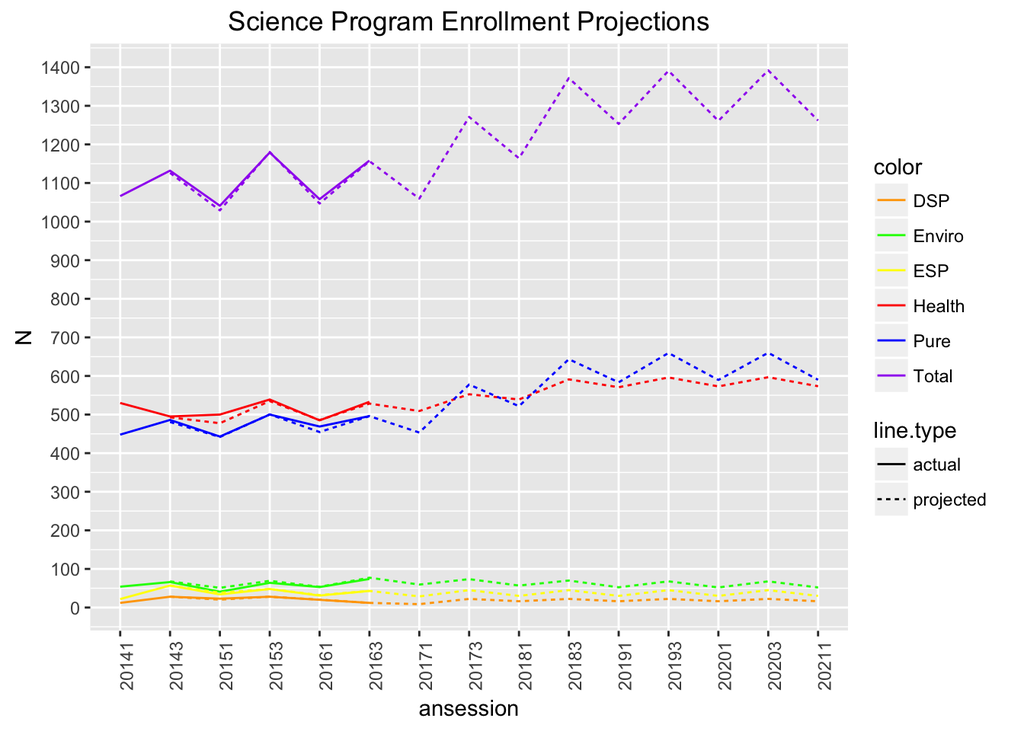

Finally, below is the data that the above figure is built upon.

```r
enrollment.history[order(ansession,program),.(ansession,program,round(N))] %>% knitr::kable()
```

| ansession | program | V3 |
| --- | --- | --- |
| 20141 | Total | 1066 |
| 20141 | ESP | 22 |
| 20141 | DSP | 12 |
| 20141 | Enviro | 54 |
| 20141 | Health | 530 |
| 20141 | Pure | 448 |
| 20143 | Total | 1132 |
| 20143 | ESP | 57 |
| 20143 | DSP | 28 |
| 20143 | Enviro | 66 |
| 20143 | Health | 495 |
| 20143 | Pure | 486 |
| 20143 | Enviro.projected | 68 |
| 20143 | Health.projected | 493 |
| 20143 | Pure.projected | 481 |
| 20143 | DSP.projected | 28 |
| 20143 | ESP.projected | 57 |
| 20143 | Total.projected | 1126 |
| 20151 | Total | 1041 |
| 20151 | ESP | 34 |
| 20151 | DSP | 23 |
| 20151 | Enviro | 41 |
| 20151 | Health | 500 |
| 20151 | Pure | 443 |
| 20151 | Enviro.projected | 51 |
| 20151 | Health.projected | 478 |
| 20151 | Pure.projected | 442 |
| 20151 | DSP.projected | 20 |
| 20151 | ESP.projected | 38 |
| 20151 | Total.projected | 1029 |

[output cut: 90 more lines]